# The Effects of Global Warming On Hurricanes

Group 311C: Kai Tsuyoshi, Jason Fu, William Fan, Fei Qin, Nihar Simhadri

**Background**

Hurricanes are among the most intimidating weather phenomenons that thanks to our latitudinal position, has never terrorized Wisconsin. However, many of these tropical storms have caused immense damage to other states, such as Hurricane Katrina, Harvey, and Ike, usually in southern states where conditions for hurricanes to form are met more frequently. Those factors are warm waters, uniform wind, and a moist atmosphere, factors that we believe, as humans continue to produce and release green-house gases into the atmosphere, become more common. Global warming has become a ticking time bomb for the planet earth, and according to NASA’s climate page [^1], just in the US, precipitation, sea level, and overall seasonal temperature will definitely continue to rise, and has been rising (at a significant rate) for the past half century, which we believe will create ideal situations for the formation of more severe and damaging tropical storms. We see evidence of increasing effects of global warming in the same page [^2], were it is stated that “the planet’s average surface temperature has risen 2.12 degrees Fahrenheit since the late 19th century” which is attributed to carbon dioxide emissions into the atmosphere, and that the ocean, the natural cooling system of the earth, has absorbed most of this increased temperature, consequently decreasing ice mass and increasing precipitation. Thus, we will explore hurricane data over the course of 127 years (1893-2020) to seek to prove that since factors of hurricanes are met more with increases in green-house gases, the frequency and strength (based on monetary damages, speed, frequency and deaths caused) of hurricanes show evidence of being increasingly powerful, proving that global warming is indeed a factor.

**Questions of Interest**

- Which season produces the most hurricanes?
- What are the lengths of hurricanes over the years?
  - Are there any trends in the frequency or lengths that are significant?
- How have wind speeds of hurricanes changed over time?
- Which year had the most damaging hurricanes, and overall, how have monetary damages trended over the years?
- Which year had the most hurricane related fatalities?

**Data**

The data used was extracted by a python program from a Wikipedia page [^3] about hurricanes and was collected for a project from CS220 about hurricanes, made available by the instructors [^4]. This data is a sample of the largest and most damaging hurricanes that were dubbed with a name, and other smaller, more insignificant hurricanes, or ones that did not receive a name, were excluded. It is missing a sizable chunk of years in the middle due to a lack of hurricanes that year, but some years have multiple. Plus, Wikipedia tends to have a bad reputation in academics as a informational resource, however, when individual hurricanes are cross-checked with other resources of more “trustworthiness”, the data can be confirmed as very accurate. The table below gives an idea of the variables included in the data set, as well as the format each is in.

```
## # A tibble: 6 × 6
##   name     formed     dissipated   mph damage deaths
##   <chr>    <chr>      <chr>      <dbl> <chr>   <dbl>
## 1 Baker    08/18/1950 09/01/1950   105 2.55M      38
## 2 Camille  08/14/1969 08/22/1969   175 1.42B     259
## 3 Eloise   09/13/1975 09/24/1975   125 560M       80
## 4 Frederic 08/29/1979 09/15/1979   130 1.77B      12
## 5 Elena    08/28/1985 09/04/1985   125 1.3B        9
## 6 Opal     09/27/1995 10/06/1995   150 4.7B       63
```

There are six variables: name, date formed (in mm/dd/yyyy), date dissipated (in mm/dd/yyyy), speed(mph), damage (in dollars followed by K, M, or B to signify thousand, million, and billion), and deaths. It should also be noted that most of the hurricane speeds are rounded quite a bit, as that information is difficult to accurately measure, especially for the greater half of the data set, where the technology for such measurements did not exist or were not as accurate as modern times. Thus, most of the speeds are rounded to multiples of five. With this data in hand, we can now begin manipulating it to display various variable relationships.

**Methods**

To begin, the season containing the most hurricanes is determined. This is accomplished by taking each date a hurricane was formed, and split them into month, day, and year, from which a season can be assigned, split into three-month periods, with March-May as Spring, June-August as Summer, September-November as Fall, and December-February as Winter. Visualizing this information, we can now see which season produces the most hurricanes. Additionally, we can subtract the date dissipated from the date formed, which we now establish as the length of each hurricane, and in combination with the prior seasonal categorization, create a bar graph visual displaying the total length of hurricanes in each year and its frequency (color-coded by season within that year).

To tackle the third question of exploring the monetary damages associated with hurricanes and finding significant trends, the values of the damage column must be converted to numerical values, rather than strings, which make looking through the data easy, but are useless when attempting to manipulate. Each damage observation contained either a “K” (Thousand), “M” (Million), or a “B” (Billion), which were removed, and the remaining value was multiplied by the numerical version of what each letter signified, yielding a malleable numerical variable column. The average damage of each year was calculated, and visualized per year by a line graph, with an accompanying trendline to indicate any significant patterns.

In similar fashion, the death toll per year was summarized, and a line graph created with a trend line to be compared with the monetary damage graph to determine whether there existed a correlation between the damage of each hurricane and the amount of deaths.

**Analysis**

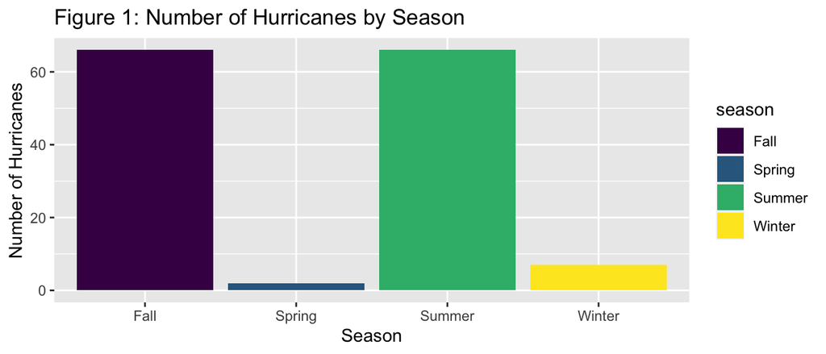

Here, it is safely assumed that summer and fall are the most common seasons during which hurricanes form.

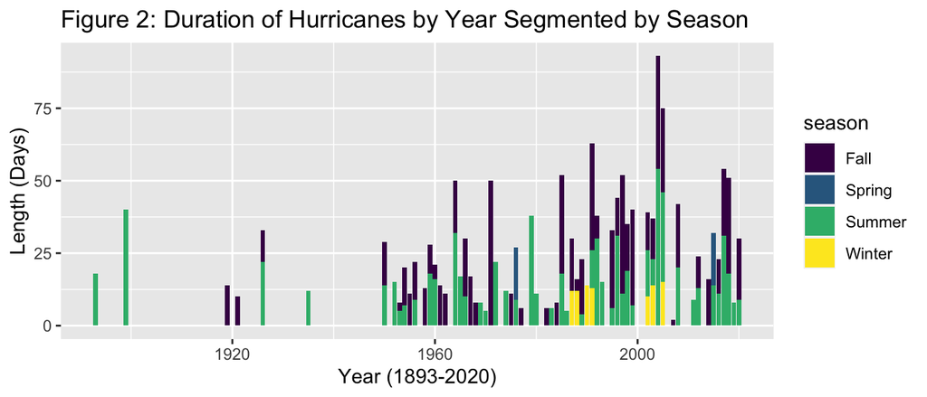

It is observed that there is a gradual cluster forming of years containing hurricane seasons of significant length as time moves closer and closer to the present day, with some years having over one-month-long hurricane seasons, with the longest in the early 2000s, spanning almost three months. The clustering effect indicates increased frequency of years that experience a tropical storm of significance (as previously stated, minor storms not deserving names have been excluded from the data set).

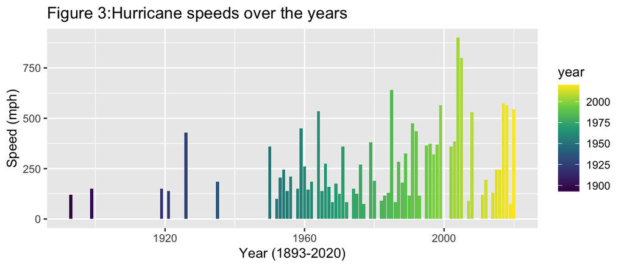

```
## # A tibble: 6 × 2
##    year      damage
##   <dbl>       <dbl>
## 1  2017 73639250000
## 2  2012 35905000000
## 3  2005 26130000000
## 4  2011 14200000000
## 5  2018 13588525000
## 6  2008 11997500000
```

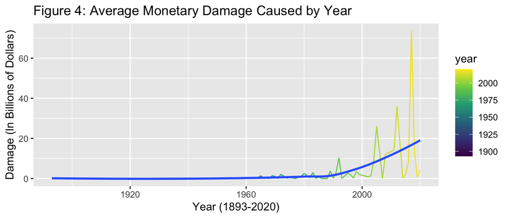

The graph displays an upward trend in damage over the years, and at an exponential rate. Up until the 1960s, almost no damage can be seen, which is testament to simply how costly the most recent storms have been in comparison. 2017 was the costliest year by far, with hurricanes Harvey, Maria, and Irma being the massive players contributing to the mind-boggling number of 74 billion dollars in damage, on average for that year.

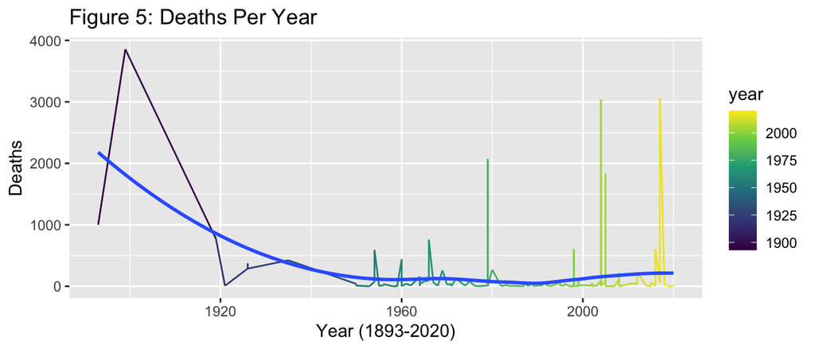

Here, it can be observed that deaths as a result of hurricanes have been decreasing over the course of the observations. Most significantly, there is a large spike in death toll in the early 1900s, and afterwards, decreases exponentially until around the 1990s, after which a small but noticeable increase in deaths can be seen. This could be attributed to the aforementioned top ranking years in costs, where those suffering the most monetary damages also suffered staggering fatalities, which the trend line downplays as the surrounding years’ small death tolls suppress the regression line.

**Conclusion**

[^1]: https://climate.nasa.gov/effects/
[^2]: https://climate.nasa.gov/evidence/
[^3]: https://en.wikipedia.org/wiki/List_of_United_States_hurricanes
[^4]: https://github.com/msyamkumar/cs220-f21-projects/tree/main/p6